# ProFound/ProFit: A Complex Fit

Aaron Robotham

2017-12-07

Load some libraries:

```r
library(ProFound)
library(ProFit)
```

```
## Running ProFound:
```

```
## Supplied image contains image and header components
```

```
## Supplied image is 356 x 356 pixels
```

```
## Extracted pixel scale from header provided: 0.339 asec/pixel
```

```
## Supplied image is 2.011 x 2.011 amin,  0.001 deg-sq
```

```
## Making initial sky map - 0.001 sec
```

```
##  - Sky statistics :
```

```
##    Min. 1st Qu.  Median    Mean 3rd Qu.    Max.
## -2.3257 -0.1157  0.5354  0.5499  1.0154  4.0443
```

```
##  - Sky-RMS statistics :
```

```
##    Min. 1st Qu.  Median    Mean 3rd Qu.    Max.
##   8.318   8.915   9.122   9.121   9.273   9.882
```

```
## Making initial segmentation image - 0.569 sec
```

```
##  - Running MakeSegim:
```

```
##  - Skipping making initial local estimate of the sky - User provided sky
```

```
##  - Skipping making initial local estimate of the sky RMS - User provided sky RMS
```

```
##  - Smoothing the image - 0.325 sec
```

```
##  - Watershed de-blending - 0.328 sec
```

```
##  - Skipping segmentation plot - plot set to FALSE
```

```
##  - Skipping making final local estimate of the sky - User provided sky
```

```
##  - Skipping making initial local estimate of the sky RMS - User provided sky RMS
```

```
##  - Skipping segmentation statistics - segstats set to FALSE or no segments
```

```
##  - MakeSegim is finished! - 0.344 sec
```

```
## Doing initial aggressive dilation - 0.915 sec
```

```
##  - Running MakeSegimDilate:
```

```
##  - Dilating segments - 0.001 sec
```

```
##  - Skipping segmentation statistics - segstats set to FALSE
```

```
##  - profoundMakeSegimDilate is finished! - 0.022 sec
```

```
## Making better sky map - 0.939 sec
```

```
##  - Sky statistics :
```

```
##     Min.  1st Qu.   Median     Mean  3rd Qu.     Max.
## -2.32792 -0.73111 -0.42721 -0.45022 -0.03966  0.41956
```

```
##  - Sky-RMS statistics :
```

```
##    Min. 1st Qu.  Median    Mean 3rd Qu.    Max.
##   8.317   8.697   8.799   8.822   8.982   9.199
```

```
## Calculating initial segstats - 1.154 sec
```

```
## Doing dilations:
```

```
## Iteration 1 of 6 - 1.23 sec
```

```
##  - Running MakeSegimDilate:
```

```
##  - Dilating segments - 0.001 sec
```

```
##  - Calculating segstats - 0.067 sec
```

```
##  - profoundMakeSegimDilate is finished! - 0.268 sec
```

```
## Iteration 2 of 6 - 1.533 sec
```

```
##  - Running MakeSegimDilate:
```

```
##  - Dilating segments - 0 sec
```

```
##  - Calculating segstats - 0.015 sec
```

```
##  - profoundMakeSegimDilate is finished! - 0.043 sec
```

```
## Iteration 3 of 6 - 1.579 sec
```

```
##  - Running MakeSegimDilate:
```

```
##  - Dilating segments - 0.001 sec
```

```
##  - Calculating segstats - 0.009 sec
```

```
##  - profoundMakeSegimDilate is finished! - 0.044 sec
```

```
## Iteration 4 of 6 - 1.624 sec
```

```
##  - Running MakeSegimDilate:
```

```
##  - Dilating segments - 0.001 sec
```

```
##  - Calculating segstats - 0.018 sec
```

```
##  - profoundMakeSegimDilate is finished! - 0.052 sec
```

```
## Iteration 5 of 6 - 1.678 sec
```

```
##  - Running MakeSegimDilate:
```

```
##  - Dilating segments - 0.001 sec
```

```
##  - Calculating segstats - 0.07 sec
```

```
##  - profoundMakeSegimDilate is finished! - 0.107 sec
```

```
## Iteration 6 of 6 - 1.786 sec
```

```
##  - Running MakeSegimDilate:
```

```
##  - Dilating segments - 0.001 sec
```

```
##  - Calculating segstats - 0.015 sec
```

```
##  - profoundMakeSegimDilate is finished! - 0.057 sec
```

```
## Finding CoG convergence - 1.843 sec
```

```
## Constructing final segim - 1.845 sec
```

```
## Doing final aggressive dilation - 1.881 sec
```

```
##  - Running MakeSegimDilate:
```

```
##  - Dilating segments - 0.001 sec
```

```
##  - Skipping segmentation statistics - segstats set to FALSE
```

```
##  - profoundMakeSegimDilate is finished! - 0.02 sec
```

```
## Making final sky map - 1.902 sec
```

```
##  - Sky statistics :
```

```
##    Min. 1st Qu.  Median    Mean 3rd Qu.    Max.
## -2.3270 -0.7348 -0.5039 -0.4977 -0.1780  0.5313
```

```
##  - Sky-RMS statistics :
```

```
##    Min. 1st Qu.  Median    Mean 3rd Qu.    Max.
##   8.324   8.660   8.779   8.798   8.969   9.195
```

```
## Calculating final segstats for 86 objects - 2.083 sec
```

```
##  - magzero = 30
```

```
##  - gain = NULL (ignored)
```

```
##  - pixscale = 0.339
```

```
##  - rotstats = TRUE
```

```
##  - boundstats = TRUE
```

```
## Plotting segments - 2.854 sec
```

```
## ProFound is finished! - 3.967 sec
```

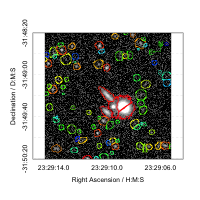

```r
image=readFITS(system.file("extdata", 'VIKING/mystery_VIKING_Z.fits', package="ProFound"))
profound=profoundProFound(image, magzero=30, verbose=TRUE, plot=TRUE, boundstats=TRUE, rotstats=TRUE)
```

We can identify the large group of central potentially confused sources from the group output from **ProFound**:

```r
profound$group$groupsegID[1,]
```

```
##   groupID                     segID Ngroup
## 1       1 1, 2, 3, 5, 6, 14, 56, 57      8
```

The main group has 8 segments, which we can view easily:

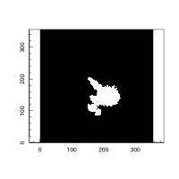

```r
magimage(profound$group$groupim==1)
```

We can check the properties of the group 1 segments too:

```r
group1segstats=profound$segstats[profound$segstats$segID %in% unlist(profound$group$groupsegID[1,"segID"]),]
group1segstats
```

```
##    segID uniqueID     xcen      ycen  xmax  ymax    RAcen    Deccen
## 1      1   222149 220.7910 148.79252 221.5 148.5 352.2866 -31.82505
## 2      2   227142 226.5476 140.89381 226.5 141.5 352.2860 -31.82579
## 3      3   194148 194.5818 147.24543 193.5 147.5 352.2895 -31.82519
## 5      5   175133 174.8384 132.82411 174.5 132.5 352.2917 -31.82655
## 6      6   178179 177.0329 179.32914 177.5 178.5 352.2915 -31.82217
## 14    14   165108 165.7946 108.83922 164.5 107.5 352.2927 -31.82881
## 56    56   180100 182.1247  96.24151 179.5  99.5 352.2909 -31.83000
## 57    57   155117 153.1687 116.03722 154.5 116.5 352.2941 -31.82813
##       RAmax    Decmax       sep         flux      mag     cenfrac
## 1  352.2866 -31.82508 0.2599896 2790717.0145 13.88571 0.033702410
## 2  352.2860 -31.82574 0.2061311 1175345.4900 14.82459 0.028589705
## 3  352.2897 -31.82517 0.3767554   71955.9488 17.85733 0.024069923
## 5  352.2918 -31.82658 0.1588496   30310.6565 18.79601 0.008326382
## 6  352.2914 -31.82225 0.3226193   42012.7303 18.44155 0.005392862
```

[output cut: 66 more lines]

In our Full Monty vignette example we detail how to extract a reasonable PSF. We use the solution here.

```r
psf_modellist=list(
  moffat=list(
    xcen=75/2,
    ycen=75/2,
    mag=0,
    fwhm=3.8,
    con=2.04,
    ang=0,
    axrat=1,
    box=0
  )
)
psf_model=profitMakeModel(modellist=psf_modellist, dim=c(75,75))$z
```

```r
maghist(profound$segstats$R50*2/0.339,breaks=20)
```

```
## [1] "Summary of used sample:"
##    Min. 1st Qu.  Median    Mean 3rd Qu.    Max.
##   2.368   4.371   5.530   6.154   7.144  25.413
## [1] "sd / 1-sig / 2-sig range:"
## [1] 3.099771 1.803710 4.376488
## [1] "Plotting 86 out of 86 (100%) data points (0 < xlo & 0 > xhi)"
```

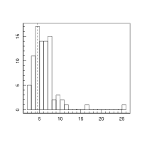

```r
abline(v=4.47, lty=2)
```

Have a quick check:

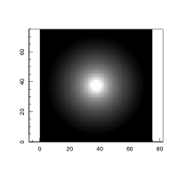

```r
magimage(psf_model)
```

```r
group1_modellist=list(
  pointsource=list(
    xcen= group1segstats$xmax[1:3],
    ycen= group1segstats$ymax[1:3],
    mag= group1segstats$mag[1:3]
  ),
  sersic=list(
    xcen= group1segstats$xmax[4:5],
    ycen= group1segstats$ymax[4:5],
    mag= group1segstats$mag[4:5],
    re= group1segstats$R50[4:5]/0.339,
    nser= rep(1, 2),
    ang= group1segstats$ang[4:5],
    axrat= group1segstats$axrat[4:5],
    box= rep(0, 2)
  )
)

group1_interval=list(
  pointsource=list(
    xcen= rep(list(c(-1,1)),3),
    ycen= rep(list(c(-1,1)),3),
    mag= rep(list(c(-2,2)),3)
  ),
  sersic=list(
    xcen= rep(list(c(-1,1)),2),
    ycen= rep(list(c(-1,1)),2),
    mag= rep(list(c(-2,2)),2),
    re= rep(list(c(0.5,2)),2),
    nser= rep(list(c(0.5,10)),2),
    ang= rep(list(c(-180,360)),2),
    axrat= rep(list(c(0.1,1)),2),
    box= rep(list(c(-1,1)),2)
  )
)
for(i in 1:3){
  group1_interval$pointsource$xcen[[i]]=group1_modellist$pointsource$xcen[i]+group1_interval$pointsource$xcen[[i]]
  group1_interval$pointsource$ycen[[i]]=group1_modellist$pointsource$ycen[i]+group1_interval$pointsource$ycen[[i]]
  group1_interval$pointsource$mag[[i]]=group1_modellist$pointsource$mag[i]+group1_interval$pointsource$mag[[i]]
}
for(i in 1:2){
  group1_interval$sersic$xcen[[i]]=group1_modellist$sersic$xcen[i]+group1_interval$sersic$xcen[[i]]
  group1_interval$sersic$ycen[[i]]=group1_modellist$sersic$ycen[i]+group1_interval$sersic$ycen[[i]]
  group1_interval$sersic$mag[[i]]=group1_modellist$sersic$mag[i]+group1_interval$sersic$mag[[i]]
  group1_interval$sersic$re[[i]]=group1_modellist$sersic$re[i]*group1_interval$sersic$re[[i]]
}

group1_tofit=list(
  pointsource=list(
    xcen= rep(TRUE, 3),
    ycen= rep(TRUE, 3),
    mag= rep(TRUE, 3)
  ),
  sersic=list(
    xcen= rep(TRUE, 2),
    ycen= rep(TRUE, 2),
    mag= rep(TRUE, 2),
    re= rep(TRUE, 2),
    nser= rep(TRUE, 2),
    ang= rep(TRUE, 2),
    axrat= rep(TRUE, 2),
    box= rep(FALSE, 2)
  )
)

group1_tolog=list(
  pointsource=list(
    xcen= rep(FALSE, 3),
    ycen= rep(FALSE, 3),
    mag= rep(FALSE, 3)
  ),
  sersic=list(
    xcen= rep(FALSE, 2),
    ycen= rep(FALSE, 2),
    mag= rep(FALSE, 2),
    re= rep(TRUE, 2),
    nser= rep(TRUE, 2),
    ang= rep(FALSE, 2),
    axrat= rep(TRUE, 2),
    box= rep(FALSE, 2)
  )
)
```

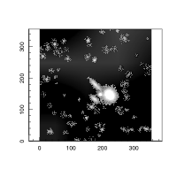

```r
sigma=profoundMakeSigma(image$imDat, objects=profound$objects, gain=0.5, sky=profound$sky, skyRMS =profound$skyRMS, plot=TRUE)
```

```r
group1_Data=profitSetupData(image$imDat-profound$sky, sigma=sigma, modellist=group1_modellist, tofit=group1_tofit, tolog=group1_tolog, intervals=group1_interval, magzero=30, algo.func='optim', psf=psf_model, region=matrix(profound$segim %in% unlist(profound$group$groupsegID[1,'segID'])[1:5], 356), verbose=FALSE)
```

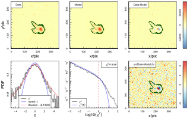

```r
profitLikeModel(parm=group1_Data$init, Data=group1_Data, makeplots=TRUE, plotchisq=TRUE)
```

Next we will run a simple optimisation scheme (because we do not have all day…)

```r
group1_fit=optim(group1_Data$init, profitLikeModel, method='BFGS', Data=group1_Data, control=list(fnscale=-1))
```

And check the results!

```r
profitLikeModel(parm=group1_fit$par, Data=group1_Data, makeplots=TRUE, plotchisq=TRUE)
```

[output not shown]

That is looking pretty pretty pretty good. A bit of residual structure in the central part, but that is as we might expect seeing as we did not attempt to create a more complex (e.g. elliptical and boxy) PSF.

We can compare the inputs and outputs easily too:

```r
group1_modellist_fit=profitRemakeModellist(parm=group1_fit$par, Data=group1_Data)$modellist
group1_modellist_fit
```

[output not shown]

We can also see the change in a nicely formatted way if we use the relist function in R:

```r
relist(unlist(group1_modellist)-unlist(group1_modellist_fit), skeleton = group1_modellist)
```

[output not shown]

The stars have migrated position a small amount, as have the extended sources. The extended sources have both hit a position limit, so it might be sensible to expand the allowed x and y centre intervals. Other parameters are barely changed, e.g. the initial **ProFound** guesses for the Re (re) and angle (ang) are actually very good. The axial ratios for the extended sources has changed a bit, but this should be expected since these are highly elliptical sources and the convolution with the PSF will be puffing them out when measured without accounting for the PSF in **ProFound**.

The two bright PSF magnitudes have changed the most, which is not surprising since they were blended together. It is notable that the raw magnitudes calculated by **ProFound** are actually nearer to the fit values than the rotstats variants. In practice, there is rarely an occasion where the raw segmented magnitudes are not a good enough a starting point for optimisation in **ProFit**, since it is in practice hard for them to be more than a factor two wrong in flux, which is easily accurate enough for a sensible starting point with **ProFit**.